# AA-GP: process null distribution

08 October, 2019

This notebook reads in results for the MultiBLUP model using 5000 random gene group to do the following:

- summarize the number of models that pass filtering criteria
- examine the distribution of the likelihood ratio (see Edwards et al 2016)
- establish 95 percentiles for heritability and the likelihood ratio

```r
knitr::opts_knit$set(root.dir = "~/Documents/AA-GenomicPrediction/",
                     warning = FALSE)
knitr::opts_chunk$set(fig.width = 10)

library(tidyverse)
library(knitr)
library(kableExtra)
```

```r
library(quantreg)
library(data.table)
library(viridis)
library(emdbook)
library(gridExtra)
library(cowplot)
```

# Size distribution of null pathways

Number of markers should have a uniform distribution

```r
null_dist <- read_csv("reports/lr_null_results.csv") %>%
  # set amino acid family ids
  mutate(
    family = ifelse(
      grepl("asp|thr|met|Asp", trait) & !grepl("ile", trait),
      "aspartate",
      ifelse(
        grepl("arg|glu|gln|pro|his|GluFam", trait),
        "glutamate",
        ifelse(
          grepl("gly|ser|SerFam", trait),
          "serine",
          ifelse(
            grepl("phe|tyr|trp|ShikFam", trait),
            "aromatic",
            "BCAA_pyruvate")))))
```

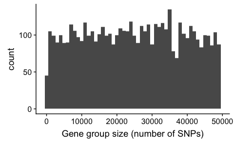

```r
null_dist %>%
  distinct(pathway, size.x) %>%
  ggplot(., aes(size.x)) +
  geom_histogram(binwidth = 1000) +
  xlab("Gene group size (number of SNPs)")
```

# Filtering

Filter out values where the REML model did not converge

Set negative heritability estimates to zero

Export summary to S2 table

```r
S2table <- null_dist %>%
  group_by(trait) %>%
  filter(Component %in% "Share_K1") %>%
  mutate("Number of gene groups" = ifelse(SD < 0 | LR < 0, 0, 1),
         "Failed to converge" = ifelse(SD < 0, 1, 0),
         "Negative LR" = ifelse(LR < 0, 1, 0)) %>%
  select("Number of gene groups", "Failed to converge", "Negative LR") %>%
  summarize_all(.funs = "sum")
S2table %>%
  write_csv(., "reports/tableS2_null_summary.csv")

head(S2table)
```

| trait | Number of gene groups | Failed to converge | Negative LR |
| --- | --- | --- | --- |
| ala | 4998 | 1 | 1 |
| ala_PyrFam | 4958 | 26 | 17 |
| ala_t | 4998 | 0 | 2 |
| arg | 4996 | 0 | 4 |
| arg_GluFam | 4997 | 1 | 3 |
| arg_t | 4992 | 6 | 4 |

Apply filters to null distribution

```r
null_dist <- null_dist %>%
  mutate(Share = ifelse(Share < 0, 0, Share),
         Share = ifelse(Share > 1, 1, Share)) %>%
  rename(size = "size.x",
         n_genes = "n_genes.x") %>%
  # remove values where SD of heritability is strange (results in inflated LR)
  filter(SD > 0 & LR >= 0 &
           Component %in% "Share_K1") %>%
  dplyr::select(family, trait, pathway, size, n_genes, group_size, null_llik,
                gblup_llik, LR, Component, Share, SD)

head(null_dist)
```

| family | trait | pathway | size | n_genes | group_size | null_llik | gblup_llik | LR | Component | Share | SD |
| --- | --- | --- | --- | --- | --- | --- | --- | --- | --- | --- | --- |
| BCAA_pyruvate | ala_PyrFam | c_1 | 46893 | 6169 | (40000,50000] | 513.8695 | 511.5969 | 4.5452 | Share_K1 | 0.47329 | 0.282042 |
| BCAA_pyruvate | ala_t | c_1 | 46893 | 6169 | (40000,50000] | 734.8466 | 733.2728 | 3.1476 | Share_K1 | 1.00000 | 0.625744 |
| BCAA_pyruvate | ala | c_1 | 46893 | 6169 | (40000,50000] | 180.1908 | 179.1117 | 2.1582 | Share_K1 | 1.00000 | 0.522908 |
| glutamate | arg_GluFam | c_1 | 46893 | 6169 | (40000,50000] | 975.5754 | 975.5582 | 0.0344 | Share_K1 | 0.47165 | 1.119568 |
| glutamate | arg_t | c_1 | 46893 | 6169 | (40000,50000] | 697.8164 | 697.7658 | 0.1012 | Share_K1 | 0.00000 | 0.826091 |
| glutamate | arg | c_1 | 46893 | 6169 | (40000,50000] | 644.6305 | 644.6289 | 0.0032 | Share_K1 | 0.19872 | 0.642089 |

# Likelihood ratio

## Distribution

Expect LR to be distributed as $\chi^2_{df 1}$~ based on Wilks’ Theorem

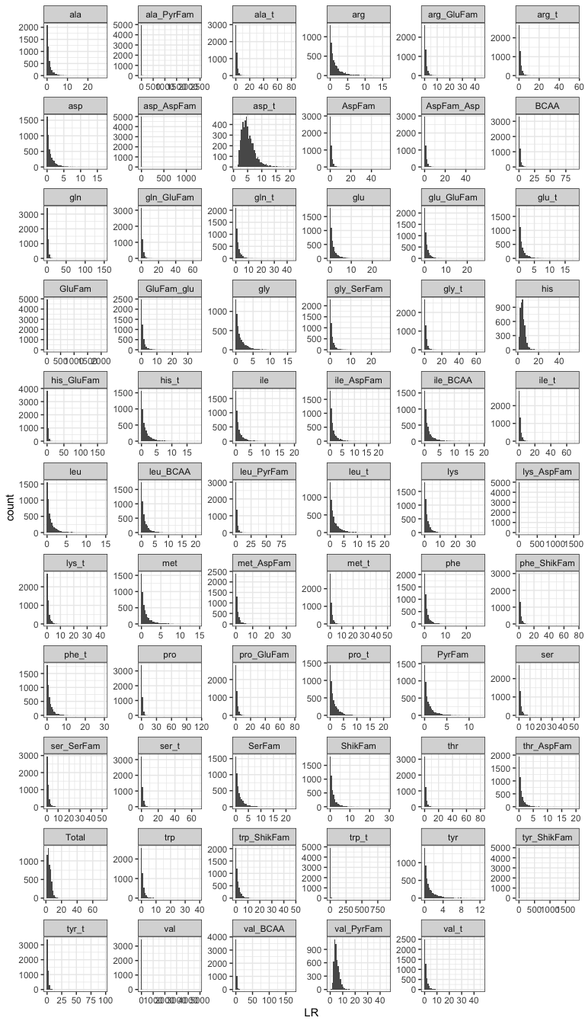

```r
null_dist %>%
    ggplot(., aes(LR)) +
    geom_histogram(bins = 50) +
  facet_wrap(~trait, scales = "free", ncol = 6) +
  theme_bw()
```

```r
# ggsave("reports/figures/null_histogram.png", height = 12, width = 8)
```

## QQ plots

Maybe some inflation at smaller group sizes (< 10,000 SNPs)

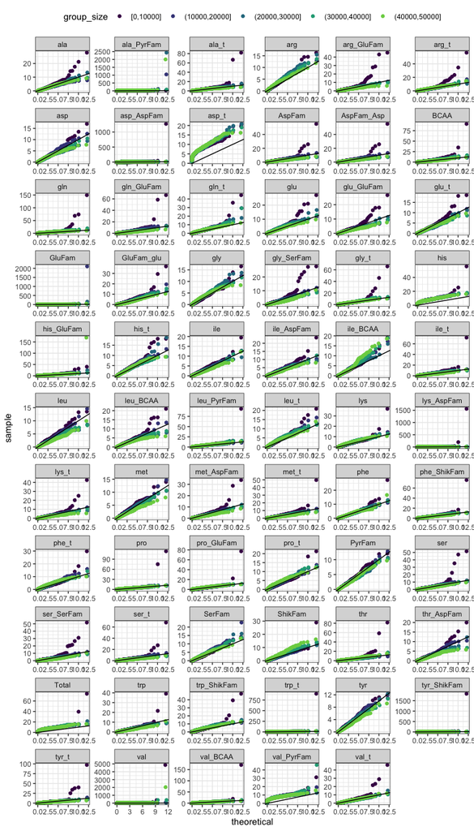

```r
null_dist %>%
  mutate(group_size = fct_relevel(group_size, "[0,10000]")) %>%
  ggplot(., aes(sample = LR, colour = group_size)) +
  scale_colour_manual(values = viridis(6)[1:5]) +
  stat_qq(distribution = qchisq, dparams = list(df = 1)) +
  facet_wrap( ~ trait, scales = "free", ncol = 6) +
  geom_abline(slope = 1, intercept = 0) +
  theme_bw() +
  theme(legend.position = "top")
```

```r
# ggsave("reports/figures/FigS5.png", height = 12, width = 8)
```

## LR goodness-of-fit tests

Test if LR follows Wilks’ theorem expectation of $\chi^2$ distribution

- $\chi^2$ test
- Kolmogorov-Smirnov test (D)

```r
# return table of results
GoF %>%
  kable(digits = 4) %>%
  kable_styling(bootstrap_options = "striped")
```

| trait | LR | D1 | D1_2 | D2 | X2_1 | X2_1_2 | X2_2 |
| --- | --- | --- | --- | --- | --- | --- | --- |
| ala | 0.9632 | 0.0199 | 0.1612 | 0.3204 | 0.3370 | 0.3370 | 0.3370 |
| ala_PyrFam | 9.3969 | 0.8439 | 0.7815 | 0.7319 | 0.3123 | 0.3123 | 0.3123 |
| ala_t | 1.1433 | 0.0490 | 0.1092 | 0.2648 | 0.3334 | 0.3334 | 0.3334 |
| arg | 1.3576 | 0.0965 | 0.0605 | 0.2184 | 0.3305 | 0.3305 | 0.3305 |
| arg_GluFam | 0.9099 | 0.0371 | 0.1888 | 0.3374 | 0.3384 | 0.3384 | 0.3384 |
| arg_t | 1.0948 | 0.0242 | 0.1376 | 0.2855 | 0.3351 | 0.3351 | 0.3351 |
| asp | 0.9778 | 0.0081 | 0.1586 | 0.3026 | 0.3364 | 0.3364 | 0.3364 |
| asp_AspFam | 1.3471 | 0.0395 | 0.1175 | 0.2691 | 0.3342 | 0.3342 | 0.3342 |
| asp_t | 5.2304 | 0.8313 | 0.7365 | 0.6517 | 0.3142 | 0.3142 | 0.3142 |
| AspFam | 0.8508 | 0.0480 | 0.1888 | 0.3482 | 0.3392 | 0.3392 | 0.3392 |
| AspFam_Asp | 0.8508 | 0.0480 | 0.2042 | 0.3482 | 0.3392 | 0.3392 | 0.3392 |
| BCAA | 1.0631 | 0.0101 | 0.1590 | 0.2988 | 0.3359 | 0.3359 | 0.3359 |
| gln | 1.4961 | 0.1233 | 0.0406 | 0.1903 | 0.3285 | 0.3285 | 0.3285 |
| gln_GluFam | 0.9171 | 0.0403 | 0.1989 | 0.3416 | 0.3396 | 0.3396 | 0.3396 |
| gln_t | 1.3770 | 0.0915 | 0.0772 | 0.2197 | 0.3305 | 0.3305 | 0.3305 |
| glu | 1.2029 | 0.0576 | 0.1035 | 0.2535 | 0.3320 | 0.3320 | 0.3320 |
| glu_GluFam | 0.8404 | 0.0469 | 0.1981 | 0.3449 | 0.3386 | 0.3386 | 0.3386 |
| glu_t | 0.8764 | 0.0382 | 0.1885 | 0.3406 | 0.3388 | 0.3388 | 0.3388 |
| GluFam | 4.8189 | 0.6607 | 0.5505 | 0.4587 | 0.3135 | 0.3135 | 0.3135 |
| GluFam_glu | 0.9594 | 0.0420 | 0.1947 | 0.3428 | 0.3385 | 0.3385 | 0.3385 |
| gly | 1.2283 | 0.0771 | 0.0858 | 0.2347 | 0.3309 | 0.3309 | 0.3309 |
| gly_SerFam | 0.8403 | 0.0623 | 0.2083 | 0.3643 | 0.3411 | 0.3411 | 0.3411 |
| gly_t | 1.1752 | 0.0493 | 0.1048 | 0.2581 | 0.3322 | 0.3322 | 0.3322 |
| his | 4.6380 | 0.7598 | 0.6432 | 0.5215 | 0.3149 | 0.3149 | 0.3149 |
| his_GluFam | 1.3010 | 0.0616 | 0.0942 | 0.2444 | 0.3313 | 0.3313 | 0.3313 |
| his_t | 1.1729 | 0.0505 | 0.1096 | 0.2639 | 0.3343 | 0.3343 | 0.3343 |
| ile | 0.9342 | 0.0216 | 0.1599 | 0.3144 | 0.3374 | 0.4039 | 0.3374 |
| ile_AspFam | 1.0235 | 0.0181 | 0.1425 | 0.2951 | 0.3350 | 0.3350 | 0.3350 |
| ile_BCAA | 1.2308 | 0.0518 | 0.1160 | 0.2607 | 0.3333 | 0.3333 | 0.3333 |
| ile_t | 1.1607 | 0.0430 | 0.1054 | 0.2636 | 0.3338 | 0.3338 | 0.3338 |
| leu | 0.8823 | 0.0301 | 0.1818 | 0.3293 | 0.3378 | 0.3378 | 0.3378 |
| leu_BCAA | 0.9897 | 0.0191 | 0.1545 | 0.2936 | 0.3352 | 0.3352 | 0.3352 |
| leu_PyrFam | 1.2495 | 0.0704 | 0.0911 | 0.2432 | 0.3317 | 0.3317 | 0.3317 |
| leu_t | 1.3821 | 0.1090 | 0.0630 | 0.2045 | 0.3296 | 0.3296 | 0.3296 |
| lys | 1.3720 | 0.1072 | 0.0538 | 0.2005 | 0.3292 | 0.3292 | 0.3292 |
| lys_AspFam | 1.5394 | 0.0452 | 0.1089 | 0.2613 | 0.3331 | 0.3331 | 0.3331 |
| lys_t | 0.8006 | 0.0651 | 0.2153 | 0.3658 | 0.3404 | 0.3404 | 0.3404 |
| met | 0.9377 | 0.0204 | 0.1671 | 0.3184 | 0.3374 | 0.3374 | 0.3374 |
| met_AspFam | 0.8335 | 0.0530 | 0.1967 | 0.3488 | 0.3390 | 0.3390 | 0.3390 |
| met_t | 0.8713 | 0.0503 | 0.2007 | 0.3521 | 0.3395 | 0.3395 | 0.3395 |
| phe | 0.9840 | 0.0138 | 0.1550 | 0.3104 | 0.3364 | 0.3364 | 0.3364 |
| phe_ShikFam | 1.0801 | 0.0274 | 0.1405 | 0.2834 | 0.3349 | 0.3349 | 0.3349 |
| phe_t | 1.2917 | 0.0804 | 0.0818 | 0.2332 | 0.3781 | 0.3301 | 0.3301 |
| pro | 1.1411 | 0.0503 | 0.1047 | 0.2612 | 0.3327 | 0.3327 | 0.3327 |
| pro_GluFam | 1.2221 | 0.0664 | 0.0854 | 0.2433 | 0.3316 | 0.3316 | 0.3316 |
| pro_t | 1.3065 | 0.0994 | 0.0627 | 0.2090 | 0.3297 | 0.3297 | 0.3297 |
| PyrFam | 0.9262 | 0.0235 | 0.1647 | 0.3184 | 0.3374 | 0.3374 | 0.3374 |
| ser | 0.9526 | 0.0259 | 0.1780 | 0.3237 | 0.3375 | 0.3375 | 0.3375 |
| ser_SerFam | 0.8285 | 0.0627 | 0.2103 | 0.3648 | 0.3405 | 0.3405 | 0.3405 |
| ser_t | 0.8381 | 0.0557 | 0.2081 | 0.3523 | 0.3393 | 0.3393 | 0.3393 |
| SerFam | 1.2536 | 0.0744 | 0.0828 | 0.2381 | 0.3309 | 0.3309 | 0.3309 |
| ShikFam | 1.2594 | 0.0653 | 0.1020 | 0.2510 | 0.3317 | 0.3317 | 0.3317 |
| thr | 1.0424 | 0.0095 | 0.1541 | 0.3049 | 0.3365 | 0.3365 | 0.3365 |
| thr_AspFam | 0.8075 | 0.0595 | 0.2189 | 0.3600 | 0.3404 | 0.3404 | 0.3404 |
| Total | 4.2856 | 0.6954 | 0.5724 | 0.4583 | 0.3145 | 0.3145 | 0.3145 |
| trp | 0.8414 | 0.0511 | 0.2054 | 0.3505 | 0.3400 | 0.3400 | 0.3400 |
| trp_ShikFam | 1.4797 | 0.1301 | 0.0438 | 0.1935 | 0.3278 | 0.3278 | 0.3278 |
| trp_t | 2.2464 | 0.2554 | 0.1244 | 0.0917 | 0.3212 | 0.3212 | 0.3212 |
| tyr | 0.9791 | 0.0136 | 0.1557 | 0.3095 | 0.3367 | 0.3367 | 0.3367 |
| tyr_ShikFam | 1.6545 | 0.0823 | 0.0811 | 0.2261 | 0.3308 | 0.3308 | 0.3308 |
| tyr_t | 0.9933 | 0.0159 | 0.1476 | 0.3024 | 0.3358 | 0.3358 | 0.3358 |
| val | 3.1229 | 0.4383 | 0.3555 | 0.3010 | 0.3106 | 0.3106 | 0.3106 |
| val_BCAA | 1.1885 | 0.0587 | 0.1068 | 0.2520 | 0.3324 | 0.3324 | 0.3324 |
| val_PyrFam | 5.0828 | 0.8408 | 0.7504 | 0.6710 | 0.3154 | 0.3154 | 0.3154 |
| val_t | 1.0384 | 0.0213 | 0.1410 | 0.2956 | 0.3355 | 0.3355 | 0.3355 |

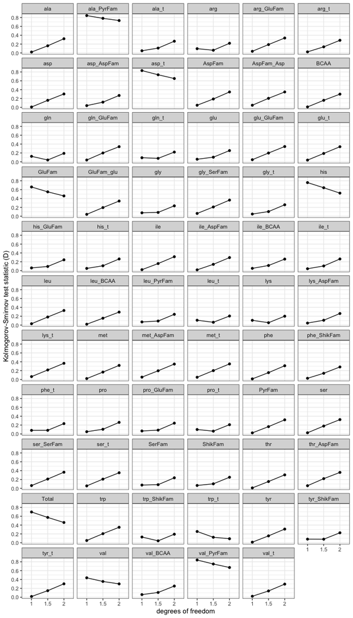

```r
# plot results
GoF %>%
  select(trait, D1, D1_2, D2) %>%
  gather(key = df, value = D, -trait) %>%
  mutate(df = recode(df, D1 = "1", D1_2 = "1.5", D2 = "2")) %>%
  ggplot(., aes(df, D, group = trait)) +
  geom_point() +
  geom_line() +
  xlab("degrees of freedom") +
  ylab("Kolmogorov-Smirnov test statistic (D)") +
  facet_wrap(~ trait, scales = "fixed", ncol = 6) +
  theme_bw() +
  theme(legend.position = "none")
```

```r
# ggsave("reports/figures/FigS4.png", height = 12, width = 10)
```

```r
GoF %>%
  select(trait, D1, D1_2, D2) %>%
  gather(key = df, value = D, -trait) %>%
  group_by(trait) %>%
  mutate(df = recode(df, D1 = "1", D1_2 = "1.5", D2 = "2")) %>%
  slice(which.min(D)) %>%
  ungroup() %>%
  write_csv("reports/goodness_of_fit.csv") %>%
  head()
```

| trait | df | D |
| --- | --- | --- |
| ala | 1 | 0.01993741 |
| ala_PyrFam | 2 | 0.73194946 |
| ala_t | 1 | 0.04901998 |
| arg | 1.5 | 0.06050000 |
| arg_GluFam | 1 | 0.03712659 |
| arg_t | 1 | 0.02421647 |

# Empirical thresholds

## 95 percentile for LR

Fit an additive quantile regression to establish 95 percentile cut off for LR at different pathway sizes (number of markers)

| family | trait | pathway | size | n_genes | group_size | null_llik | gblup_llik | LR | Component | Share | SD | lr_95 | col |
| --- | --- | --- | --- | --- | --- | --- | --- | --- | --- | --- | --- | --- | --- |
| BCAA_pyruvate | ala_PyrFam | c_1 | 46893 | 6169 | (40000,50000] | 513.8695 | 511.5969 | 4.5452 | Share_K1 | 0.47329 | 0.282042 | 14.5406 | FALSE |
| BCAA_pyruvate | ala_t | c_1 | 46893 | 6169 | (40000,50000] | 734.8466 | 733.2728 | 3.1476 | Share_K1 | 1.00000 | 0.625744 | 4.3082 | FALSE |
| BCAA_pyruvate | ala | c_1 | 46893 | 6169 | (40000,50000] | 180.1908 | 179.1117 | 2.1582 | Share_K1 | 1.00000 | 0.522908 | 4.0260 | FALSE |
| glutamate | arg_GluFam | c_1 | 46893 | 6169 | (40000,50000] | 975.5754 | 975.5582 | 0.0344 | Share_K1 | 0.47165 | 1.119568 | 3.3996 | FALSE |
| glutamate | arg_t | c_1 | 46893 | 6169 | (40000,50000] | 697.8164 | 697.7658 | 0.1012 | Share_K1 | 0.00000 | 0.826091 | 4.4198 | FALSE |
| glutamate | arg | c_1 | 46893 | 6169 | (40000,50000] | 644.6305 | 644.6289 | 0.0032 | Share_K1 | 0.19872 | 0.642089 | 5.1292 | FALSE |

## 95 percentile for $h^2$

Fit an additive quantile regression to establish 95% quantile cut off for proportion of genomic variance explained (H^2) at different pathway sizes (number of markers)

| trait | size | h2_95 |
| --- | --- | --- |
| ala_PyrFam | 16 | 1.590172e-12 |
| ala_PyrFam | 48 | 1.615621e-11 |
| ala_PyrFam | 70 | 2.556116e-02 |
| ala_PyrFam | 79 | 3.601800e-02 |
| ala_PyrFam | 83 | 3.601800e-02 |
| ala_PyrFam | 84 | 3.601800e-02 |

## Plot null distribution

Blue dots are pathways that also pass the LR_95 threshold  
Solid line is the 95% percentile for proportion of heritability explained  
Dashed line is the infinitesimal expectation (each SNP contributes approximately equal amount of variation)

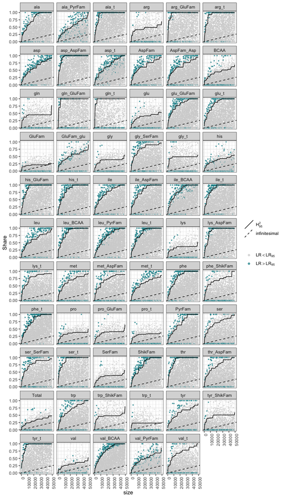

```r
null_dist %>%
  ggplot(., aes(size, Share, colour = col)) +
  scale_colour_manual(values = c("light grey", "#1c9099"),
                      labels = c(expression(paste(LR < LR[95])),
                                 expression(paste(LR > LR[95])))) +
  geom_point(position = position_dodge(width = 0.3), aes(size = col), alpha = 0.75) +
  scale_size_manual(guide = "none", values = c(0.1, 0.5)) +
  geom_quantile(method = "rqss", lambda = 500, quantiles = c(0.95),
                formula = as.formula(y ~ qss(x, constraint = "I")),
                aes(linetype = factor(..quantile..)),
                colour = "black", show.legend = FALSE) +
  geom_abline(aes(intercept = 0, slope = 1/199452, linetype = "dashed")) +
  scale_linetype_manual(labels = c(expression(paste(H[95]^2)),
                                   "infinitesimal"),
                        values = c(1,2)) +
  facet_wrap( ~ trait, ncol = 6) +
  xlim(0, 50000) +
  theme_bw() +
  theme(axis.text.x = element_text(angle = 90, hjust = 1),
        legend.title = element_blank(),
        legend.text.align = 0)
```

```r
# ggsave("reports/figures/S2Fig.tiff", height = 12, width = 10)
```

# save results

```r
save(lr_fit, h2_fit, file = "reports/null_distribution.RData")
```